# Task 2: Willamette Falls salmon

Nick McManus

2023-03-18

```r
knitr::opts_chunk$set(echo = TRUE, message = FALSE, warning = FALSE)
library(tidyverse)
library(lubridate)
library(tsibble)
library(fable)
library(feasts)
```

# Introduction:

This task explores Willamette Falls fish ladder passage data, including daily time series data, seasonplots, and annual counts. The data used for this analysis are accessed from the Columbia River Data Access in Real Time (DART) and collected by the Oregon Department of Fish and Wildlife (ODFW). Fish counting occurs at the ladder main viewing window and uses video cameras and time lapsed video to record data 24 hours a day, every day. This analysis specifically examings the passage of adult coho (*Oncorhynchus kisutch*), jack coho, and steelhead (*Oncorhynchus mykiss*) salmon between Jan 1, 2001 and Dec 31, 2010. “Jack” salmon are defined as males that reach sexual maturation and return to spawn in freshwater one year earlier than full-size adult males. These jack coho are identifiable by different coloration [(SeaGrant).](https://alaskaseagrant.org/2022/07/research-shows-how-jack-salmon-contribute-to-population-and-genetics/) Images of the study area and species are presented below.

**Data source:** Columbia Basin Research, University of Washington. 2023. DART Adult Passage Graphics & Text. http://www.cbr.washington.edu/dart/query/adult_graph_text

##### Fish ladder

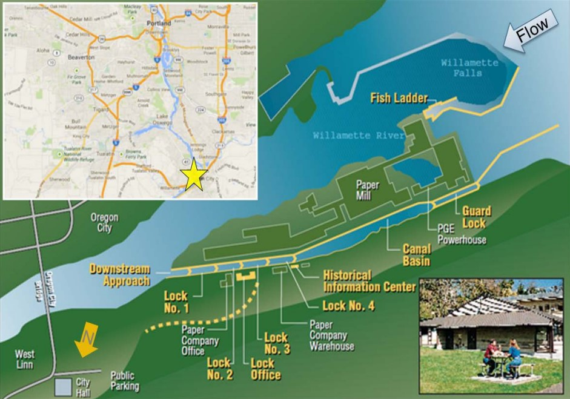

Willamette Falls fish ladder, located south of Portland, Oregon. Credit: *US Army Corps of Engineers*

##### Coho Salmon

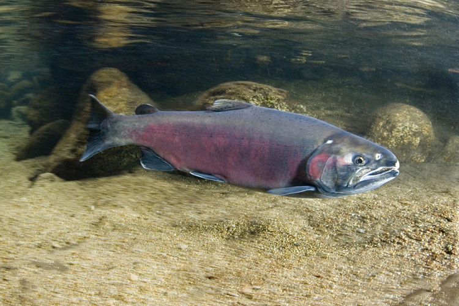

Adult coho salmon. Credit: *NOAA Fisheries*

##### Steelhead Salmon

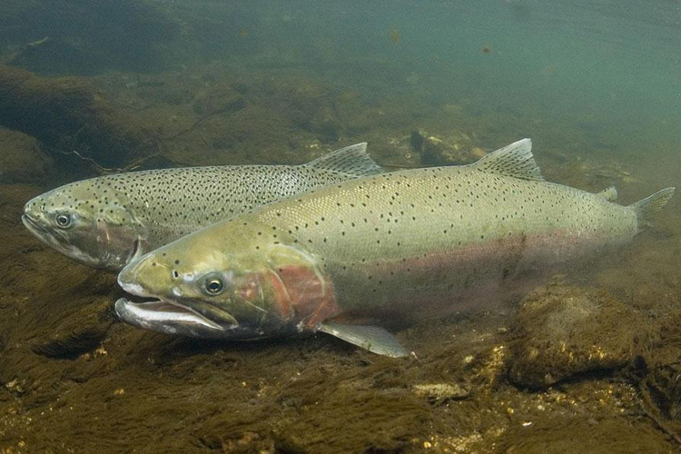

Male and female steelhead salmon. Credit: *NOAA Fisheries*

# Time series analyses:

## Original time series

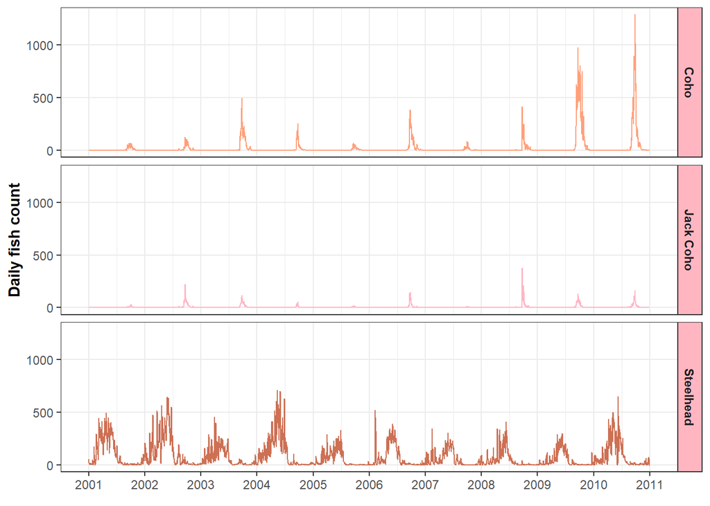

```r
### First read in, clean, and wrangle data
fish <- read_csv('willamette_fish_passage.csv')

fish_sub <- fish %>%
  janitor::clean_names() %>%
  ## return 3 fish types of interest
  select(date, steelhead, coho, jack_coho) %>%
  ## replace NAs with 0
  replace(is.na(.), 0)


# class(fish_sub$date)
# [1] "character"

### Next, convert date to date class
### and convert df to tsibble (time series df)
fish_ts <- fish_sub %>%
  mutate(date = lubridate::mdy(date)) %>%
  as_tsibble(key = NULL, index = date)

### To plot, pivot so species in same column
fish_ts_long <- fish_ts %>%
  pivot_longer(cols = 2:4,
               names_to = "species",
               values_to = "count")


## vector for facet wrap plot labels
spp_labs <- c("Coho", "Jack Coho", "Steelhead")
names(spp_labs) <- c("coho", "jack_coho", "steelhead")


### Finally, visualize data
ggplot(data = fish_ts_long, aes(x = date, y = count, color = species)) +
  geom_line(size = 0.4) +
  facet_wrap(~species, nrow = 3, strip.position = 'right',
             labeller = labeller(species = spp_labs)) +
  labs(x = element_blank(),
       y = "Daily fish count") +
  ## customize axis with cont 'date' class data
  scale_x_date(limits = as.Date(c('2001-01-01', '2010-12-31')),
               date_breaks = "1 year",
               date_labels = "%Y") +
  scale_color_manual(values = c("lightsalmon", "pink1", "salmon3")) +
  theme_bw() +
  theme(
    axis.title = element_text(face = 'bold'),
    panel.grid.minor.y = element_blank(),
    strip.text = element_text(face = 'bold'),
    strip.background = element_rect(fill = 'lightpink'),
    legend.position = "none"
  )
```

**Figure 1:** Time series for adult coho, jack coho, and steelhead salmon passage through the Willamette Falls fish ladder between 2001 and 2010.

- There are far fewer jack coho than coho salmon, indicating that occurrence of precocial males is uncommon for *O. kisutch*.
- The annual steelhead passage remains fairly consistent between 2001 and 2010, while passage counts for coho are more variable.
- There is no obvious correlation between annual patterns of coho and steelhead counts. This relationship could be further explored to more accurately determine if annual population size between these salmon species are significantly correlated.

## Seasonplots

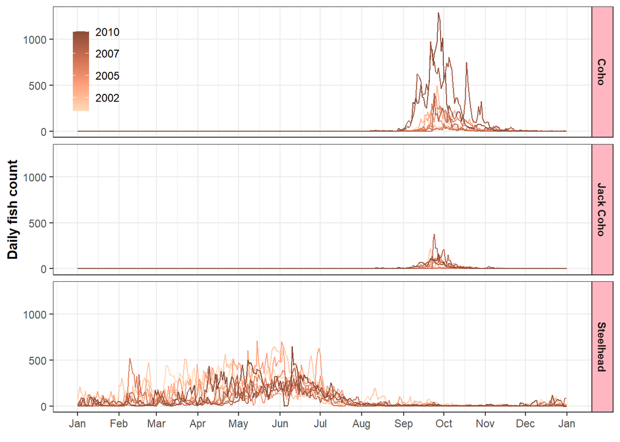

```r
### plot with feasts::gg_season()
fish_ts_long %>%
  gg_season(y = count,
            pal = c('peachpuff', 'lightsalmon', 'salmon3', 'salmon4')) +
  facet_wrap(~species, nrow = 3, strip.position = 'right',
             labeller = labeller(species = spp_labs)) +
  labs(x = element_blank(),
       y = 'Daily fish count') +
  scale_x_date(date_breaks = "1 month",
               date_labels = "%b") +
  theme_bw() +
    theme(
    axis.title = element_text(face = 'bold'),
    panel.grid.minor.y = element_blank(),
    strip.text = element_text(face = 'bold'),
    strip.background = element_rect(fill = 'lightpink'),
    legend.background = element_blank(),
    legend.text = element_text(size = 9),
    legend.position = c(0.08, 0.85),
    legend.key.size = unit(0.9, 'line')
  )
```

**Figure 2:** Seasonplots for coho, jack coho, and steelhead salmon passage through the Willamette Falls fish ladder. Colored lines ranging from light to dark pink represent years 2001 through 2010, respectively.

- Coho and jack coho salmon (*O. kisutch*) pass through the Willamette Falls ladder during a smaller time window than steelhead (*O. mykiss*).
- The majority *O. kisutch* passage occurs during autumn (Sep - Nov), while steelhead *O. mykiss* passage occurs throughout the winter to summer months (Jan - Aug). As such, there is little overlap between *O. kisutch* and *O. mykiss* at Willamette Falls.

## Annual counts

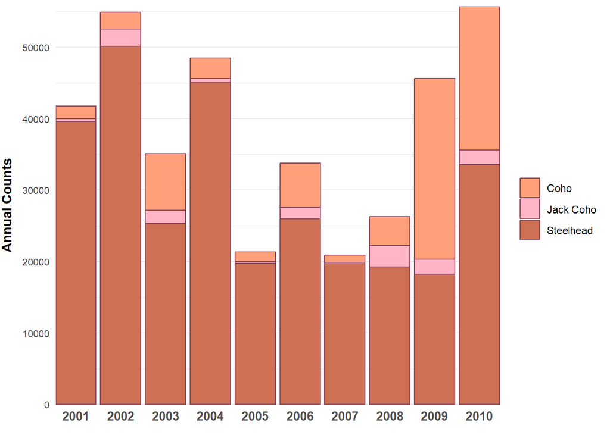

```r
### create new df with annual totals by spp
fish_count_yr <- as.data.frame(fish_ts_long) %>%
  mutate(year = lubridate::year(date)) %>%
  select(-date) %>%
  group_by(year, species) %>%
  summarize(yr_count = sum(count))

### some sample stats
fish_stats_yr <- fish_count_yr %>%
  group_by(species) %>%
  summarize(mean = mean(yr_count),
            sd = sd(yr_count))


### Visualize annual counts
ggplot(data = fish_count_yr, aes(x = year, y = yr_count)) +
  geom_col(aes(fill = species),
           color = "palevioletred4") +
  scale_fill_manual(values = c("lightsalmon", "pink1", "salmon3"),
                     labels = c("Coho", "Jack Coho", "Steelhead")) +
  scale_x_continuous(breaks = seq(from = 2001, to = 2010, by = 1),
                     expand = c(0,0)) +
  scale_y_continuous(expand = c(0,0)) +
  labs(x = element_blank(),
       y = "Annual Counts") +
  theme_minimal() +
  theme(
    axis.title.y = element_text(face = 'bold', vjust = 3),
    axis.text.x = element_text(face = 'bold', size = 10),
    axis.text.y = element_text(size = 8),
    panel.grid.minor.x = element_blank(),
    panel.grid.major.x = element_blank(),
    legend.title = element_blank()
  )
```

**Figure 3:** Annual counts of coho, jack coho, and steelhead salmon passing at the Willamette Falls fish ladder between 2001-2010. On average, steelhead salmon had an annual count of 2.965^{4} $\pm$ 1.1737^{4} while coho and jack coho had average annual counts of 7284$\pm$8500 and 1432$\pm$1009, respectively (mean $\pm$1 standard deviation).

- With the exception of 2009, steelhead salmon consistently have the highest counts during this time period.
- Overall salmon counts dropped between 2005-2008. In 2009-2010, Coho salmon counts grew much quicker than steelhead.